# 2. Exersice Sheet

von Celina Kortmann, Felix Göke und Erich Wagner

## Exersice 3 - Dice

You roll two dice, one red and one blue. What is the probability that
(a) the sum of pips is 9?
Es gibt insgesamt 4 Möglichkeiten, wie die Augenzahl der beiden Würfel 9 ergeben kann. Es gibt die Kombination (3,6) und (4,5) und jeweils andersrum. Da die Wahrscheinlichkeiten unabhängig voneinander sind (der rote Würfel beeinflusst den blauen nicht und andersrum) gilt: $P(A \wedge B)=P(A) \cdot P(B)$. Außerdem verwenden wir das 3. Kolmogorov-Axiom. $$ \begin{aligned} P(W_r+W_b=9)&=P(W_r=3 \wedge W_b=6)+P(W_r=6 \wedge W_b=3)\\ &+P(W_r=4 \wedge W_b=5)+P(W_r=5 \wedge W_b=4) \\ &=2\cdot P(W_r=3 \wedge W_b=6) + 2\cdot P(W_r=4 \wedge W_b=5)\\ &=2 \cdot P(W_r=3)\cdot P(W_b=6)+2 \cdot P(W_r=4)\cdot P(W_b=5)\\ &=2 \cdot \frac{1}{6}\cdot \frac{1}{6}+2 \cdot \frac{1}{6}\cdot \frac{1}{6}\\ &=\frac{4}{36}=\frac{1}{9} \end{aligned} $$ (b) the sum of pips is 9 or larger?
Jetzt müssen wir außerdem die Wahrscheinlichkeit dafür betrachten, dass die Augenzahl 10, 11 oder 12 ist und dann die Summe bilden. Für $W_{ges}=12$ gibt es 1 Möglichkeit, für $W_{ges}=11$ gibt es 2 Möglichkeiten. Für $W_{ges}=10$ gibt es 3 Möglichkeiten. $$ \begin{aligned} P(W_r+W_b \geq 9)=&P(W_r+W_b=9)+P(W_r+W_b=10)+P(W_r+W_b=11)+P(W_r+W_b=12) \\ &=\frac{4}{36}+\frac{3}{36}+\frac{2}{36}+\frac{1}{36} \\ &=\frac{10}{36} \end{aligned} $$ (c) one dice shows 4 and the other 5 pips? $$ \begin{aligned} P((W_r=4 \wedge W_b=5) \vee (W_r=5 \wedge W_b=4))&=P(W_r=4 \wedge W_b=5) + P(W_r=5 \wedge W_b=4) \\ &= P(W_r=4) \cdot P(W_b=5) + P(W_r=5) \cdot P(W_b=4) \\ &= \frac{1}{6} \cdot \frac{1}{6} + \frac{1}{6} \cdot \frac{1}{6} \\ &= \frac{2}{36} \\ &= \frac{1}{18} \end{aligned} $$ (d) the red dice shows 4 and the blue dice 5 pips? $$ \begin{aligned} P(W_r=4 \wedge W_b=5)&= P(W_r=4) \cdot P(W_b=5) \\ &=\frac{1}{6}\cdot \frac{1}{6} \\ &= \frac{1}{36} \end{aligned} $$

Your roll the dice so that the blue dice rolls behind an object so that you cant see it first. The red dice shows a 4. After you have seen this, what is the prabability that
(e) the sum of pips is nine?
Wenn wir wissen, dass der rote Würfel eine 4 zeigt, dann suchen wir nach der Wahrscheinlichkeit, dass der blaue Würfel eine 5 zeigt, damit die Gesamtaugenzahl 9 ist. Da die Wahrscheinlichkeiten unabhängig voneinander sind, folgt: $$ P(W_b=5| W_r=4)=P(W_b=5)=\frac{1}{6} $$

(f) the sum of pips is 9 or larger?
$$ \begin{aligned} P(W_b\geq 5|W_r=4)&=P(W_b \geq 5) \\ &=P(W_b=5 \vee W_b=6) \\ &=P(W_b=5)+P(W_b=6) \\ &=\frac{1}{6}+\frac{1}{6} \\ &=\frac{2}{6}\\ &=\frac{1}{3} \end{aligned} $$

(g) the red dice shows 4 and the blue dice 5 pips?  
This is the same as (e), weil $W_b=5$ gleichbedeutend mit einer Gesamtaugenzahl von 9 ist, mit dem Wissen, dass der rote Würfel eine 4 zeigt, was unsere Annahme für die Aufgabenteile (e), (f) und (g) ist.

## Exercise 4 - Maxwell velocity distribution

The probability density of the magnitude of the velocity 𝑣 of the molecules in an ideal gas at the absolute temperature 𝑇 is given by $$ f(v)=N\cdot \exp \left( -\frac{m v^2}{2k_B T} \right) \cdot 4 \pi v^2, $$ where 𝑚 is the molecular mass, $k_B$ is the Boltzmann constant, and 𝑁 is the normalization constant.

(a) How big is the most probable velocity $v_m$?
Die Geschwindigkeit mit der größten Wahrscheinlichkeit ist das Maximum der Maxwellverteilung und folgt somit aus der Gleichung $df(v)/dv=0$. Bevor diese Rechnung durchgeführt wird, führen wir die Variable $a=\frac{m}{2 k_B T}$ ein, damit ergibt sich: $$ \begin{aligned} 0&=\frac{d}{dv}\left( \frac{4}{\sqrt{\pi}} \cdot a^{3/2} \cdot \exp(-av^2) \cdot v^2 \right) \\ &= \frac{4}{\sqrt{\pi}} \cdot a^{3/2} \frac{d}{dv}\left(\exp(-av^2) \cdot v^2 \right) \\ &= \frac{4}{\sqrt{\pi}} \cdot a^{3/2} \left( -2av\exp(-av^2)v^2 + 2v\exp(-av^2) \right) \\ &= \frac{4}{\sqrt{\pi}} \cdot a^{3/2} \cdot \exp(-av^2) (1-av^2) \cdot 2v \end{aligned} $$ Also ist das Maximum erreicht für $v_m=\sqrt{1/a}=\sqrt{\frac{2 k_B T}{m}}$.

Die Funktion kann nun umgeschrieben werden zu: $$ f(v)=\frac{4}{\sqrt{\pi}} \cdot \frac{v^2}{v_m^3} \exp\left(-\frac{v^2}{v_m^2}\right) $$

(b) How big is the mean of the velocity $\braket{v}$?
$$ \begin{aligned} \braket{v}=\int_0^\infty f(v)vdv &= \frac{4}{\sqrt{\pi}} v_m^{-3} \int_0^\infty \exp(-\frac{v^2}{v_m^2}) v^3 dv \\ &=\frac{4}{\sqrt{\pi}} v_m^{-3} \cdot \frac{1}{2} \Gamma(2) \cdot (v_m^2)^2 \\ &=\frac{2}{\sqrt{\pi}}v_m \end{aligned} $$

(c) How big is the median of the velocity $v_{0.5}$?
Gesucht ist $$ \begin{aligned} F(v_{0.5})&=\int_{-\infty}^{v_{0.5}}f(v)dv=0.5 \\ 0&=\text{erf}(\beta)-\frac{2}{\sqrt{\pi}}\cdot \beta \cdot \exp{(-\beta^2)}-0.5 \end{aligned} $$ mit $\beta=v_{0.5}/v_m$.

```python
import numpy as np
import matplotlib.pyplot as plt
import scipy as sc
from scipy import special
from scipy import optimize
import matplotlib_inline
matplotlib_inline.backend_inline.set_matplotlib_formats('png','pdf')
def f(x):
    return special.erf(x) -2/np.sqrt(np.pi)*x*np.exp(-x**2)- 1/2
```

```python
median=sc.optimize.root_scalar(f, x0=0, x1=1).root
print(f'Der Median der Geschwindigkeitsverteilung ist {median:.3f} mal v_m')
```

```
Der Median der Geschwindigkeitsverteilung ist 1.088 mal v_m
```

Somit ist der Median der Geschwindigkeit $v_{0.5}\approx 1.088 \cdot v_m$.

(d) How big is the full width at half height of the distribution $(v_\text{FWHM})$?
Die halbe Höhe entspricht $f(v)=0.5\cdot f(v_m)$. $$ 0.5 \cdot f(v_m)= \frac{2}{\sqrt{\pi}} v_m^{-3} \exp(-\frac{v_m^2}{v_m^2}) v_m^2=\frac{2}{\sqrt{\pi}v_m} \exp(-1) $$ Daraus folgt: $$ \begin{aligned} 0&= \frac{4}{\sqrt{\pi}} v_m^{-3} \exp(-\frac{v_w^2}{v_m^2}) v_w^2 - \frac{2}{\sqrt{\pi}v_m} \exp(-1) \\ \Rightarrow 0&=2 \gamma^2 \exp(-\gamma^2)-\exp(-1) \end{aligned} $$ mit $\gamma=v_w/v_m$.

```python
def g(x):
    return (2*x**2*np.exp(-(x)**2)-np.exp(-1))

v_w1=sc.optimize.root_scalar(g, x0=0, x1=1.1).root
v_w2=sc.optimize.root_scalar(g, x0=1, x1=2).root
print(f'Die linke Punkt ist {v_w1:.3f} mal v_m')
print(f'Der rechte Punkt ist {v_w2:.3f} mal v_m')
print(f'Daraus ergibt sich eine breite von {(v_w2-v_w1):.3f} mal v_m')
```

```
Die linke Punkt ist 0.482 mal v_m
Der rechte Punkt ist 1.637 mal v_m
Daraus ergibt sich eine breite von 1.155 mal v_m
```

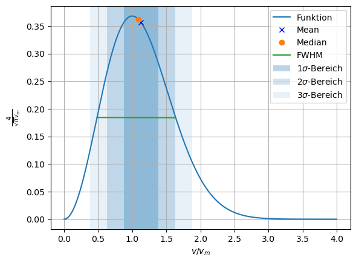

```python
#Darstellung der Ergebnisse:
def F(x):
    return x**2*np.exp(-x**2)

v_mean=2/np.sqrt(np.pi)
v_median=1.088
v_w1=0.482
v_w2=1.637
sigma=1/4

x=np.linspace(0,4,1000)
plt.plot(x,F(x), label='Funktion')
plt.plot(v_mean,F(v_mean), 'xb',label='Mean')
plt.plot(v_median, F(v_median), 'o', label='Median')
plt.plot([v_w1,v_w2], [F(v_w1), F(v_w2)], '-', label='FWHM')
#plt.plot(v_mean-sigma, F(v_mean-sigma),'o', label=r'$-\sigma$')
#plt.plot(v_mean+sigma, F(v_mean+sigma),'o', label=r'$+\sigma$')
plt.axvspan(v_mean-sigma, v_mean+sigma, alpha=0.3,label=r'$1 \sigma$-Bereich')
plt.axvspan(v_mean-2*sigma, v_mean+2*sigma, alpha=0.2,label=r'$2 \sigma$-Bereich')
plt.axvspan(v_mean-3*sigma, v_mean+3*sigma, alpha=0.1,label=r'$3 \sigma$-Bereich')
plt.xlabel(r'$v/v_m$')
plt.ylabel(r'$\frac{4}{\sqrt{\pi}v_m}$')
plt.legend(loc='best')
plt.grid(True)                          # grid style
```